# Guia análisis de cluster

Métodos de análisis no paramétricos

Dr. José A. Gallardo.

Profesor adjunto de la Pontificia Universidad Católica de Valparaíso  
jose.gallardo@pucv.cl

May 22, 2022

#### Objetivos de aprendizaje

Realizar análisis de cluster usando **software R**.

#### Conceptos importantes

**¿Qué son los análisis de cluster?** Son herramientas de exploración de datos que permiten agrupar y visualizar datos multivariados con base a su similitud.

**Clasificación de análisis de cluster** **Jerárquico:** Los grupos se fusionan sucesivamente siguiendo una jerarquía de homogeneidad, la cual decrece a medida que se agregan más elementos al grupo.

**No jerárquico:** Se forman grupos homogéneos sin establecer relaciones o jerarquía entre ellos.

#### Software.

Esta es la versión de R que se usó para crear esta guía.

```r
R.version.string
```

```
## [1] "R version 4.0.3 (2020-10-10)"
```

#### Librerías.

**{stats}**  
This package contains functions for statistical calculations and random number generation.

**{readxl}**  
Read Excel Files.

**{dplyr}**  
Librería para manipular datos.

**{vegan}** Librería que implementa métodos de ordenación y diversidad ecológica.

**{cluster}** Librería que implementa algoritmos para el análisis de cluster

**{factoextra}** Librería que implementa algoritmos para el análisis de cluster y visualización usando ggplot2

#### Comandos para realizar los análisis.

**read_excel()**  
Importa datos a R desde archivos excel.

**select** Selecciona variables desde un data.frame o una tibble.

**%>%** El operador pipe sirve para concatenar tareas o funciones.

**mutate()** Crea nuevas variables a partir de variables originales de un data.frame o una tibble.

**t()** Dada una matriz x, t() entrega la transpuesta x.

**dist()** Calcula diferentes matrices de distancia entre las filas de un conjunto de datos.

**vegdist()** Calcula diferentes medidas de distancia o similaridad (usualmente para datos de ecología) entre las filas de un conjunto de datos.

**hclust()** Realiza análisis de cluster jerarquico sobre una matriz de disimilaridad.

**scale()** Función para escalar y centrar variables, util para los análisis de cluster.

#### EJERCICIOS

Realice los ejercicios de forma colaborativa con uno o dos compañeros.

Elabore un archivo Rmarkdown o file con extensión **.R** en Rstudio o Rstudio.cloud.

Habilite los paquetes **readxl**, **dplyr**, **vegan**, **psych**, **cluster** y **factoextra** usando la función **library()**.

**Estudio de caso: Poliquetos submareales**

Durante el crucero de investigación CIMAR 17 Fiordos se colectaron muestras de Poliquetos submareales de fondo blando en 23 estaciones desde el Estero Reloncaví a boca del Guafo [Rozbaczylo y colaboradores](http://www.shoa.cl/n_cendhoc/productos/cimar17/resumenes/08_nicolas_rozbaczylo.pdf).

Para cada estación los investigadores calcularon los siguientes índices ecológicos:

- Riqueza de especies (S).
- Diversidad específica (H) según Shannon-Weaver.
- Índice de equidad (J) según Pielou.

A partir del set de datos **poliquetos.xlsx** realice los siguientes ejercicios.

**Ejercicio 1.** Importar y explorar

1. Importe la hoja 1 set de datos **poliquetos.xlsx** usando la función *read_excel()* del paquete *readxl*. No olvide usar el argumento *Sheet=1*. Explore el set de datos usando las funciones *summary()*. Compruebe que todas las variables numéricas están expresadas como número y que las variable Estaciones sea un factor. Caso contrario realice los cambios correspondientes con las funciones **as.numeric()** y **as.factor()**.

```r
poliqueto <- read_excel("poliquetos.xlsx", sheet = 1)
summary(poliqueto)
```

```
##    Estaciones         S                J                H
##  Min.   : 1.0   Min.   : 2.000   Min.   :0.5110   Min.   :0.611
##  1st Qu.: 6.5   1st Qu.: 5.500   1st Qu.:0.7730   1st Qu.:1.215
##  Median :12.0   Median : 8.000   Median :0.8570   Median :1.689
##  Mean   :12.0   Mean   : 8.043   Mean   :0.8315   Mean   :1.668
##  3rd Qu.:17.5   3rd Qu.:10.000   3rd Qu.:0.9135   3rd Qu.:2.142
##  Max.   :23.0   Max.   :14.000   Max.   :0.9570   Max.   :2.407
```

```r
poliqueto$Estaciones <- as.factor(poliqueto$Estaciones)
str(poliqueto)
```

```
## tibble [23 × 4] (S3: tbl_df/tbl/data.frame)
##  $ Estaciones: Factor w/ 23 levels "1","2","3","4",..: 1 2 3 4 5 6 7 8 9 10 ...
##  $ S         : num [1:23] 4 10 13 14 7 8 8 5 3 2 ...
##  $ J         : num [1:23] 0.734 0.945 0.875 0.912 0.857 0.812 0.957 0.827 0.727 0.881 ...
##  $ H         : num [1:23] 1.02 2.18 2.24 2.41 1.67 ...
```

2. Elabore una gráfica de correlaciones de las variables S, H y J usando la función **pairs.panels()**.

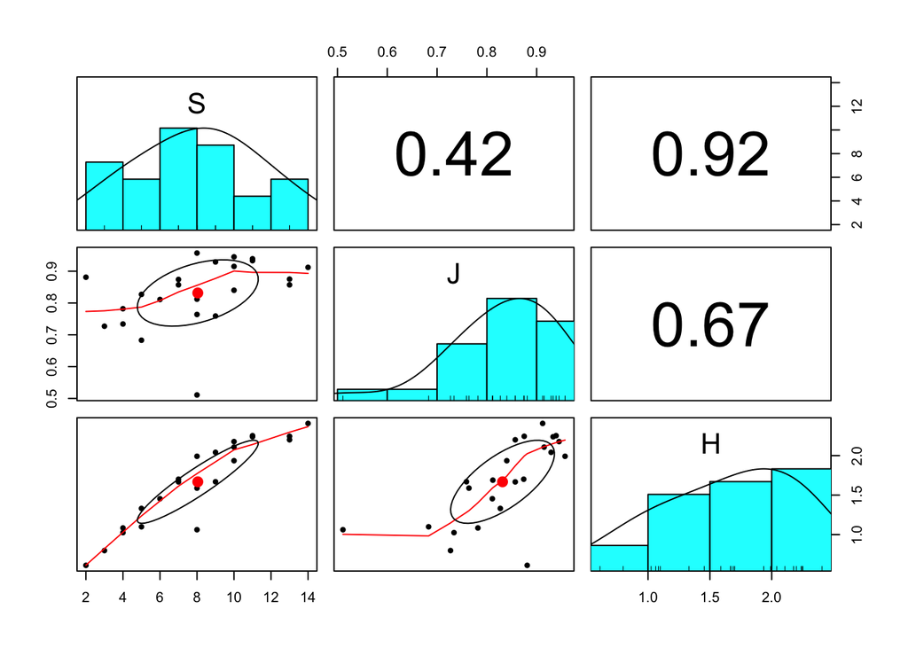

```r
pairs.panels(poliqueto[2:4])
```

**Ejercicio 2.** Cluster jerárquico.

1. Para las tres variables cuantitativas continuas S, H y J elabore 3 variables derivadas S1, H1 y J1 con su *valor estandarizado* como la diferencia de cada valor por la media **mean()** y dividiendo por la desviación estandar **sd()**. Use la función **mutate()** de la librería **dplyr**

```r
# Crea nuevas variables
val_estandarizado <- poliqueto %>%
 select(S, H, J) %>%
 mutate(
  S1 = (S - mean(S)) / sd(S),
  J1 = (J - mean(J)) / sd(J),
  H1 = (H - mean(H)) / sd(H))
```

2. Elabore una gráfica de correlaciones de las variables estandarizadas usando la función **pairs.panels()** y compare con las correlaciones estimadas en el ejercicio **1b** que calcula la correlación con la variable original.

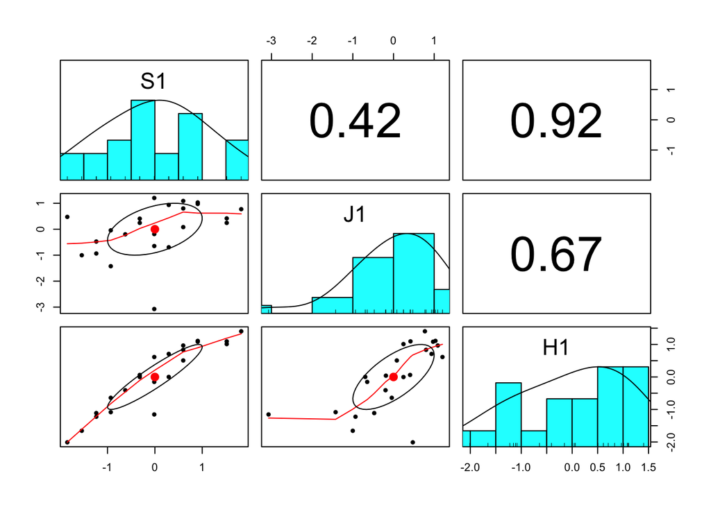

```r
pairs.panels(val_estandarizado[4:6])
```

3. Calcule la matriz de distancia euclideana estandarizada para las estaciones 1 a 23 usando los tres Índices ecológicos (S1,H1,J1). Use la función **dist()**.

```r
# distance matrix
d <- dist(val_estandarizado[4:6], method = "euclidean")
```

Extrae primeros 6 elementos de la matriz

```r
d_matriz <- as.matrix(d)
d_matriz[1:6,1:6]
```

```
##          1        2         3         4         5         6
## 1 0.000000 3.502340 3.8456462 4.3803363 1.9300651 1.9112401
## 2 3.502340 0.000000 1.1443421 1.3377924 1.5798366 1.6919631
## 3 3.845646 1.144342 0.0000000 0.5618268 2.1459806 1.9545624
## 4 4.380336 1.337792 0.5618268 0.0000000 2.6167853 2.4810544
## 5 1.930065 1.579837 2.1459806 2.6167853 0.0000000 0.5306501
## 6 1.911240 1.691963 1.9545624 2.4810544 0.5306501 0.0000000
```

4. Elabore una gráfica de cluster jerarquico usando la función **hclust()**. Considere el método UPGMA usando el argumento *method=“average”*. Grafique el dendograma con la función **plot()**.

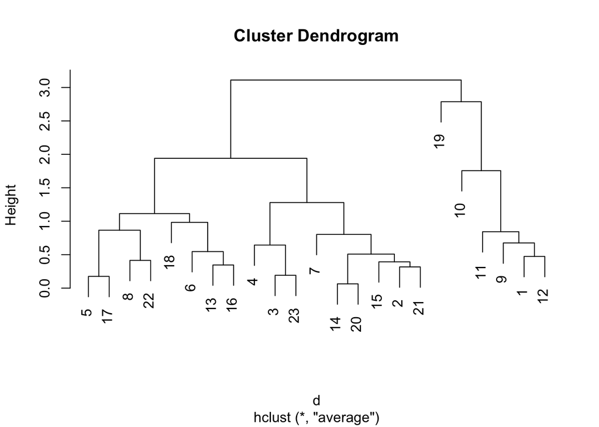

```r
fit <- hclust(d, method="average")
plot(fit)
```

**Ejercicio 3.** Cluster no jerárquico.

Ahora realizaremos un análisis de cluster no jerarquico con el método k-means y usaremos nuevas funciones para simplificar el proceso de estandarización.

1. Para las tres variables cuantitativas continuas S, H y J estandarice las variables usando la función **scale()**.

```r
poliqueto <- scale(poliqueto[2:4])
poliqueto
```

```
##                 S           J            H
##  [1,] -1.23729341 -0.93473767 -1.223582856
##  [2,]  0.59869036  1.08858165  0.967701453
##  [3,]  1.51668225  0.41733827  1.095145939
##  [4,]  1.82267954  0.77213834  1.405197452
##  [5,] -0.31930153  0.24473283 -0.002398371
##  [6,] -0.01330423 -0.18678077  0.039449072
##  [7,] -0.01330423  1.20365194  0.613900340
##  [8,] -0.93129612 -0.04294290 -0.641522961
##  [9,] -1.54329071 -1.00186201 -1.655372385
## [10,] -1.84928800  0.47487342 -2.011075654
## [11,] -0.93129612 -1.42378642 -1.082823273
## [12,] -1.23729341 -0.47445650 -1.111355621
## [13,] -0.01330423 -0.64706194 -0.152668736
## [14,]  0.90468766  1.03104650  1.110363191
## [15,]  0.29269307  0.93515459  0.709008166
## [16,]  0.29269307 -0.69500789  0.001405942
## [17,] -0.31930153  0.40774908  0.062274950
## [18,]  0.59869036  0.08171659  0.507379575
## [19,] -0.01330423 -3.07312729 -1.153203064
## [20,]  0.90468766  0.97351136  1.083733000
## [21,]  0.59869036  0.80090592  0.834550496
## [22,] -0.62529882 -0.19636996 -0.407557709
## [23,]  1.51668225  0.24473283  1.011451053
## attr(,"scaled:center")
##         S         J         H
## 8.0434783 0.8314783 1.6682609
## attr(,"scaled:scale")
##         S         J         H
## 3.2680027 0.1042841 0.5257191
```

2. Elabore y grafique una matriz de distancia ecuclideana con las funciones **get_dist()** y **fviz_dist** de la librería **factoextra**

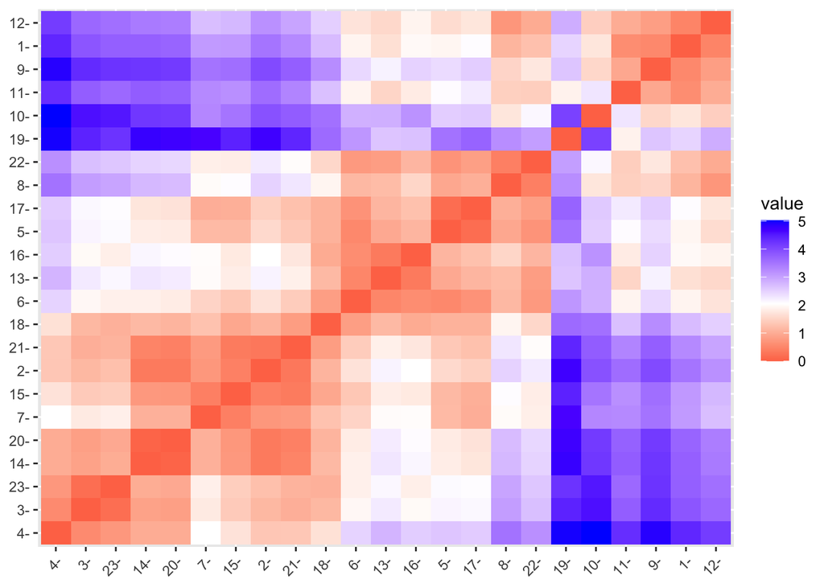

```r
distance <- get_dist(poliqueto, method = "euclidean")
fviz_dist(distance)
```

3. Realice un análisis de cluster k-means con la función **kmeans** de la librería **stats** y luego grafique con la función y **fviz_cluster()**. Suponga la existencia de 2, 3 y 4 cluster diferentes.

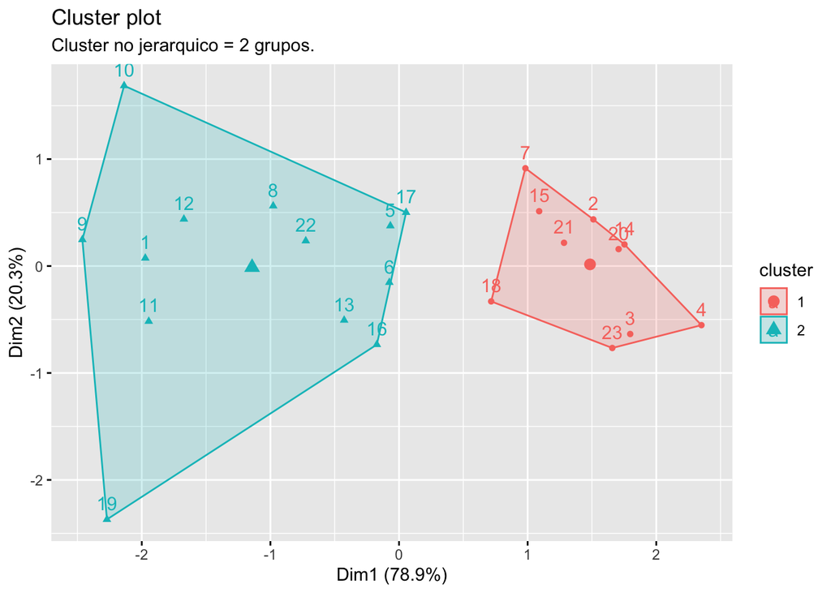

```r
k2 <- kmeans(poliqueto, centers = 2, nstart = 25)
fviz_cluster(k2, data = poliqueto)+labs(subtitle = "Cluster no jerarquico = 2 grupos.")
```

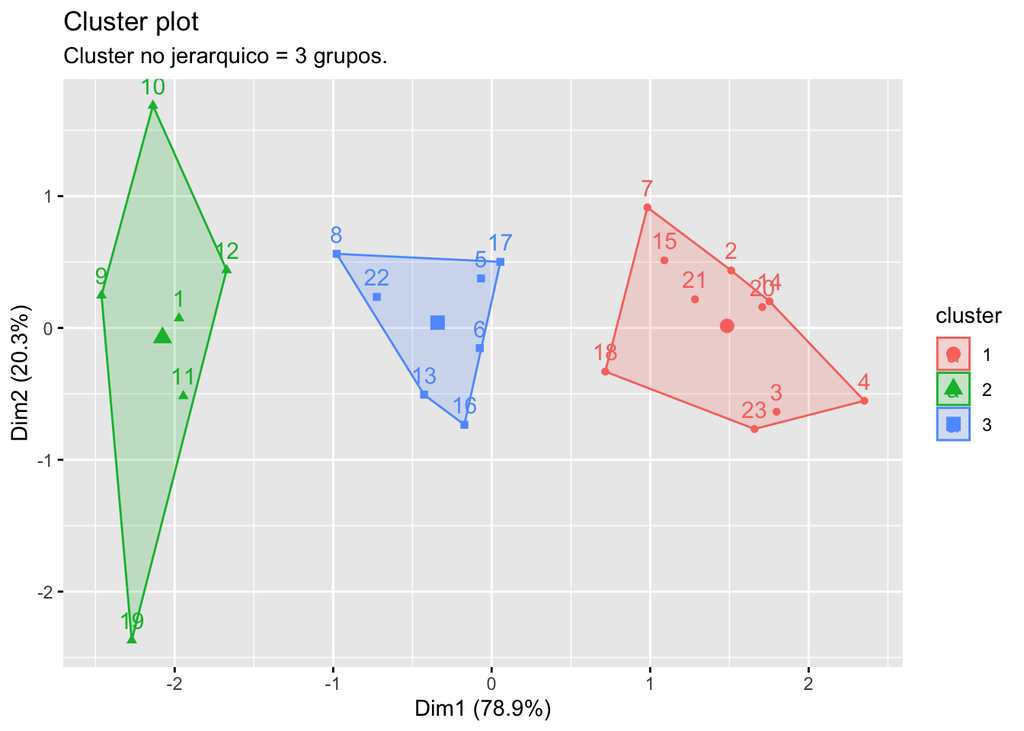

```r
k3 <- kmeans(poliqueto, centers = 3, nstart = 25)
fviz_cluster(k3, data = poliqueto)+labs(subtitle = "Cluster no jerarquico = 3 grupos.")
```

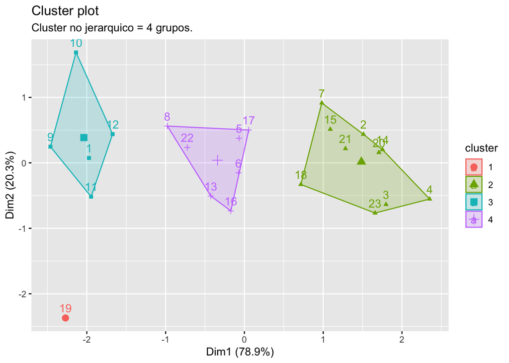

```r
k4 <- kmeans(poliqueto, centers = 4, nstart = 25)
fviz_cluster(k4, data = poliqueto)+labs(subtitle = "Cluster no jerarquico = 4 grupos.")
```

4. Note que el análisis de cluster por k-means no nos dice nada acerca de cual es el número óptimo de cluster y todos parecen dar una buena representación de los datos.

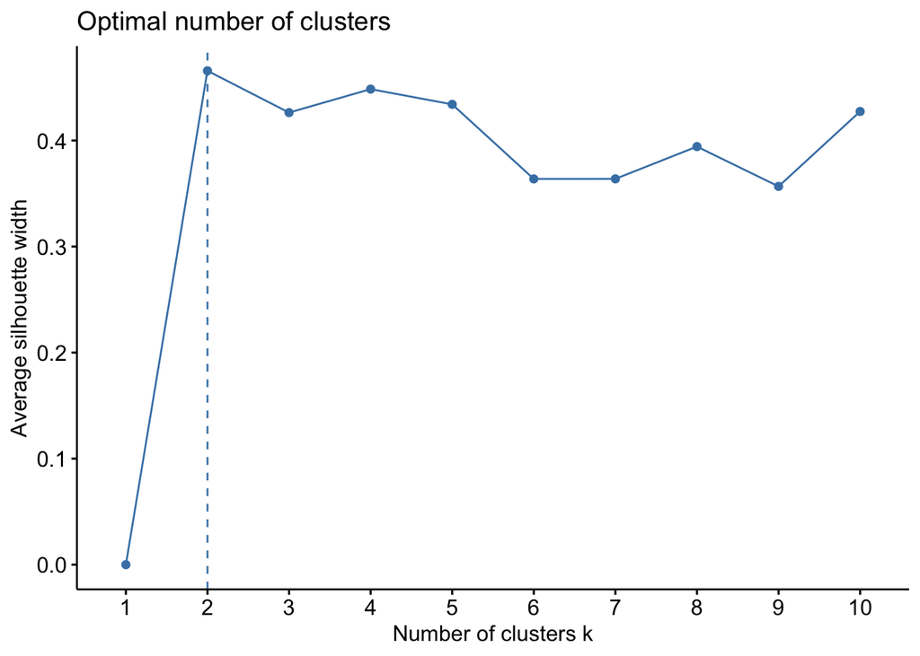

```r
cluster <- fviz_nbclust(poliqueto, kmeans, method = "silhouette")
cluster
```